# Beyond MLR Lab 3: Treatment effects across laboratories

# Estimate the simple treatment effects

We have used the regression coefficients to calculate treatment effects manually. We now use R to obtain the effects and their uncertainty for all five laboratories from the fitted model.

## Obtain estimated marginal means

**Estimated marginal means (EMMs)** are model-based estimates of group means, averaged over other factors where appropriate. We obtain these means from the fitted interaction model, then compare them to estimate treatment effects.

For simple treatment effects, keep laboratories separate and estimate the standard and experimental mean within each laboratory.

```r
treatment_means <- emmeans(model_full, ~ treatment | laboratory)
treatment_means
```

Here, `model_full` supplies the fitted model and `~ treatment | laboratory` requests treatment means **separately within each laboratory**. The command calculates these means from the fitted model.

In the output, `emmean` is the estimated mean closure, `SE` is its estimated standard error, and `lower.CL` and `upper.CL` are its 95% confidence limits. The interaction model fits a separate mean for every treatment-laboratory combination, so these estimated means equal the observed cell means in the exploratory summary.

## Compare treatments within laboratories

Use `pairs()` to compare the two predicted means within each laboratory, then `summary()` to display the treatment differences with **pointwise 95% confidence intervals** and **unadjusted p-values**.

```r
simple_effects <- pairs(treatment_means, reverse = TRUE, adjust = "none")
summary(simple_effects, infer = c(TRUE, TRUE), by = NULL)
```

Because the treatment levels are ordered Standard then Experimental, `reverse = TRUE` gives **experimental minus standard**. The column `estimate` contains the simple treatment effect in each laboratory, measured in percentage points.

In `pairs()`, `adjust = "none"` specifies pointwise intervals and unadjusted p-values. The `summary()` call uses this setting: `infer = c(TRUE, TRUE)` requests both confidence intervals and tests, and `by = NULL` displays the five comparisons together. Each p-value tests whether the treatment effect in that laboratory is zero.

The standard error for a **difference** describes uncertainty about that treatment effect. It accounts for the covariance between the predicted means. Use this standard error when interpreting the treatment comparison.

**ImportantQuestion 4**

Interpret the estimated treatment effect and its 95% confidence interval in Laboratory A. Check that its estimate agrees with your calculation from the regression coefficients. What do the estimates, confidence intervals, and unadjusted p-values suggest about the treatment effect within each laboratory? Describe the size and uncertainty of the estimated effects.

**TipModel answer 4**

Estimated treatment means and pointwise 95% confidence intervals

| Laboratory | Treatment | Mean closure (%) | Estimated SE | 95% CI: lower | 95% CI: upper |
| --- | --- | --- | --- | --- | --- |
| Laboratory A | Standard | 42.15 | 2.55 | 37.07 | 47.23 |
| Laboratory A | Experimental | 49.17 | 2.55 | 44.09 | 54.25 |
| Laboratory B | Standard | 52.38 | 2.55 | 47.30 | 57.46 |
| Laboratory B | Experimental | 54.69 | 2.55 | 49.61 | 59.77 |
| Laboratory C | Standard | 45.51 | 2.55 | 40.43 | 50.59 |
| Laboratory C | Experimental | 66.17 | 2.55 | 61.09 | 71.25 |
| Laboratory D | Standard | 56.56 | 2.55 | 51.48 | 61.64 |
| Laboratory D | Experimental | 55.23 | 2.55 | 50.15 | 60.31 |
| Laboratory E | Standard | 52.57 | 2.55 | 47.49 | 57.65 |
| Laboratory E | Experimental | 70.33 | 2.55 | 65.25 | 75.41 |

Experimental minus standard: effects and uncertainty in percentage points

| Laboratory | Estimate | Estimated SE | 95% CI: lower | 95% CI: upper | Unadjusted p-value |
| --- | --- | --- | --- | --- | --- |
| Laboratory A | 7.02 | 3.61 | -0.16 | 14.20 | 0.0551 |
| Laboratory B | 2.31 | 3.61 | -4.87 | 9.49 | 0.5242 |
| Laboratory C | 20.66 | 3.61 | 13.48 | 27.84 | <0.001 |
| Laboratory D | -1.33 | 3.61 | -8.51 | 5.85 | 0.7137 |
| Laboratory E | 17.76 | 3.61 | 10.58 | 24.94 | <0.001 |

In **Laboratory A**, experimental treatment is estimated to increase mean closure by 7.02 percentage points, agreeing with the calculation from the regression coefficients. Its estimated standard error is 3.61 percentage points, and its pointwise 95% confidence interval is -0.16 to 14.20 percentage points. The interval includes values close to zero and improvements of around 14 percentage points. With an unadjusted p-value of 0.055, there is uncertainty about the direction and size of the effect.

- **Laboratory B:** the estimated improvement is 2.31 percentage points (95% CI −4.87 to 9.49; p = 0.524). The interval includes both reduced closure and improved closure.
- **Laboratory C:** the estimated improvement is 20.66 percentage points (95% CI 13.48 to 27.84; p < 0.001). The interval supports a positive effect, with a substantial increase in mean closure on the percentage-point scale.
- **Laboratory D:** the estimated difference is −1.33 percentage points (95% CI −8.51 to 5.85; p = 0.714). The estimate is close to zero, and the interval allows effects in either direction.
- **Laboratory E:** the estimated improvement is 17.76 percentage points (95% CI 10.58 to 24.94; p < 0.001). The interval supports a positive effect, with a substantial increase in mean closure.

All five comparisons have the same estimated standard error because every treatment–laboratory group contains 10 plates and the model uses a common residual variance. The intervals and p-values describe each treatment comparison separately, using the pointwise intervals and unadjusted tests requested in the lab. For A, B, and D, the intervals show the range of effects compatible with the data under the model, including zero.

**NoteOptional: considering multiple comparisons**

When several treatment comparisons are interpreted together, an adjustment can help control the probability of at least one false-positive finding across the set. Whether this is appropriate depends on the scientific questions and how the comparisons will be used.

The **Bonferroni correction** multiplies each p-value by the number of comparisons, with a maximum of 1. Compare the adjusted p-values with 0.05. For example, across five comparisons, a p-value of 0.008 becomes 0.040.

To apply the correction, change `adjust = "none"` to `adjust = "bonferroni"` in the `pairs()` call above and rerun it, followed by the same `summary()` call. With `by = NULL`, the correction applies across all five laboratory comparisons. This also adjusts the confidence intervals.

# Check the model assumptions

Use the interaction model to create the same two residual plots used in Week 1.

```r
plot(model_full, which = 1)  # Residuals versus fitted values
plot(model_full, which = 2)  # Normal Q-Q plot
```

The residuals-versus-fitted plot helps assess whether residual spread changes with fitted closure. Vertical groups of points are expected because plates in the same treatment-laboratory group share a fitted mean. The Normal Q-Q plot assesses whether the residual distribution is approximately Normal.

The interaction model estimates each group’s mean, so residuals average to zero within every group by construction. Look for changes in spread and departures from the Normal reference line. Assess independence using the experimental design and how the plates were handled and measured.

**ImportantQuestion 5**

Do the plots suggest clear violations of the constant-variance or Normality assumptions? Describe the patterns that support your answer.

**TipModel answer 5**

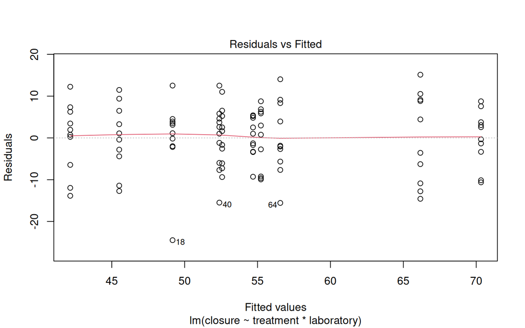

**Residuals versus fitted values:** the smooth is nearly horizontal around zero, and there is no clear increase or decrease in spread with fitted closure. Some groups have a wider spread than others, but the plot shows no systematic funnel. Constant variance appears reasonable as a working assumption.

The vertical groups occur because plates in the same treatment–laboratory group share a fitted mean. Residuals average to zero within each group because the interaction model estimates a separate mean for every group.

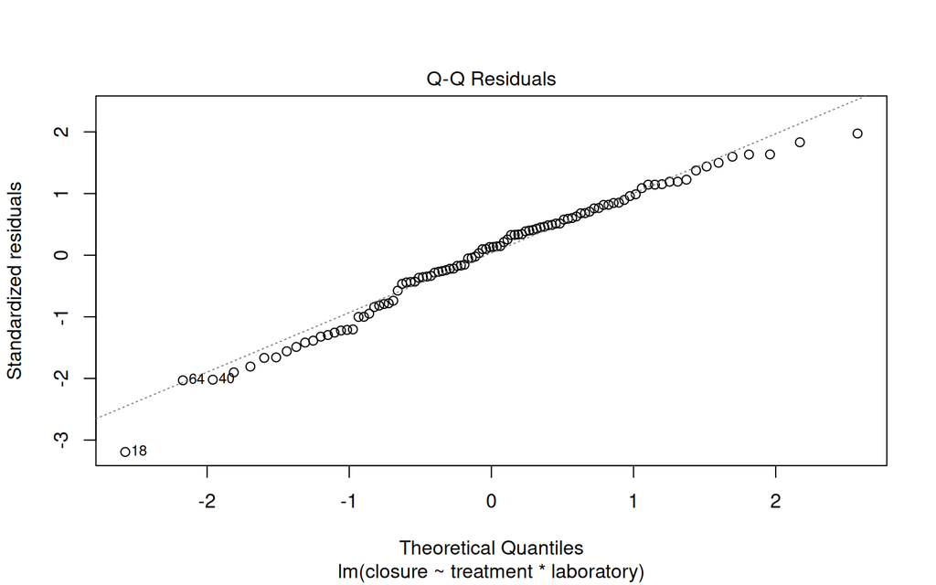

**Normal Q–Q plot:** most points follow the reference line through the middle of the distribution. There are departures in the tails: observation 18 has a particularly large negative residual, and the upper-tail points fall below the line. A Normal error distribution is a reasonable working approximation, with some tail departures worth checking, especially observation 18.